# CARTO-sf

Author

Claude Grasland

```r
# packages utilitaires
library(knitr)
library(dplyr)
library(jsonlite)

# Data packages
library(wbstats)
library(rnaturalearth)

# Packages cartographiques
library(sf)
library(geojsonsf)
library(mapsf)
```

L’importation et l’exportation de données spatiales peut se faire de différentes manières qui sont illustrées dans trois exemples. L’important est d’aboutir à un fichier de type **sf (spatial features)** combinant les données géométriques et les données statistiques dans un seul objet. Une fois créé, cet obet sera stocké au format interne de R (.RDS).

## Importation d’un shapefile

### Carte au format shapefile

Beaucoup de fonds de cartes sont stockés au format shapefile, utilisé dans les systèmes d’information géographiques (SIG). Un shapefile se compose en réalité de trois ou quatre fichiers correspondant la géométrie (*fic.shp*), à la projection (*fic.prj*), aux données attributaires (*fic.dbf*), etc..

On charge le fonds de carte au format shapefile avec la fonction `st_read()` du package **sf**. On ne lui indique que le nom du fichier de géométrie et il lit automatiquement les autres.

```r
map<-st_read("carto/europe88/euro1988_map.shp")
```

Le fichier est au format *sf* qui est le format cartographique de R. Il comporte une colonne spéciale appelée **geometry**.

```r
class(map)
```

```
[1] "sf"         "data.frame"
```

```r
head(map)
```

```
Simple feature collection with 6 features and 1 field
Geometry type: MULTIPOLYGON
Dimension:     XY
Bounding box:  xmin: 3496766 ymin: 1525952 xmax: 5448053 ymax: 2758691
Projected CRS: ETRS89-extended / LCC Europe
  ISO3                       geometry
1  ALB MULTIPOLYGON (((4777759 184...
2  AUT MULTIPOLYGON (((4494160 246...
3  BEL MULTIPOLYGON (((3728385 267...
4  BGR MULTIPOLYGON (((5260441 208...
5  CHE MULTIPOLYGON (((3968843 232...
6  CSK MULTIPOLYGON (((4327916 268...
```

On peut visualiser la carte enb effectuant un plot de la colonne geometry :

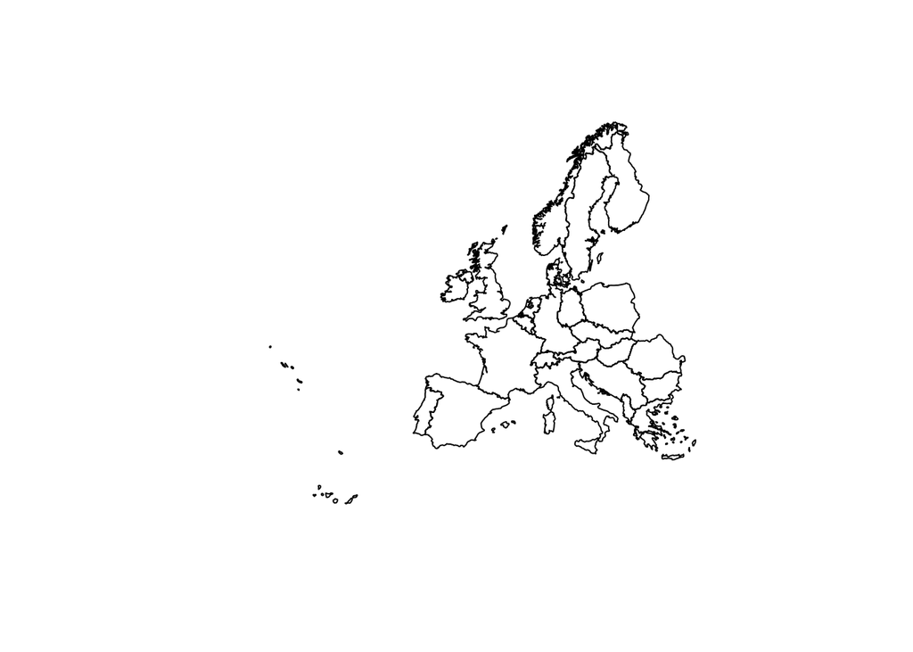

```r
plot(map$geometry)
```

### Données au format .csv

```r
don<-read.table("carto/europe88/euro1988.csv",
                sep=";",
                header=T,
                encoding = "UTF-8")
class(don)
```

```
[1] "data.frame"
```

```r
head(don)
```

```
  PAYS BLOC   PNB  TMI ESP URB NAT MOR FEC JEU VIE SUP  POP       X       Y
1  ALB  Soc   600 43.0  71  34  27   6 3.3  35   5  29  3.1 4825115 1684833
2  AUT  Cap 10000 10.3  75  55  12  12 1.4  18  14  84  7.6 4299715 2335579
3  BEL  Cap  9200  9.7  75  95  12  11 1.5  19  14  31  9.9 3636312 2667243
4  BGR  Soc  2000 14.5  72  65  13  11 2.0  21  11 111  9.0 5206070 1930219
5  CHE  Cap 17800  6.8  77  61  12   9 1.5  17  14  41  6.6 3869378 2243130
6  CSK  Soc  3200 13.9  71  74  14  12 2.0  24  11 128 15.6 4487005 2540281
```

### Jointure

```r
mapdon<-merge(map,don,by.x="ISO3",by.y="PAYS",all.x=T,all.y=T)
class(mapdon)
```

```
[1] "sf"         "data.frame"
```

```r
head(mapdon)
```

```
Simple feature collection with 6 features and 15 fields
Geometry type: MULTIPOLYGON
Dimension:     XY
Bounding box:  xmin: 3496766 ymin: 1525952 xmax: 5448053 ymax: 2758691
Projected CRS: ETRS89-extended / LCC Europe
  ISO3 BLOC   PNB  TMI ESP URB NAT MOR FEC JEU VIE SUP  POP       X       Y
1  ALB  Soc   600 43.0  71  34  27   6 3.3  35   5  29  3.1 4825115 1684833
2  AUT  Cap 10000 10.3  75  55  12  12 1.4  18  14  84  7.6 4299715 2335579
3  BEL  Cap  9200  9.7  75  95  12  11 1.5  19  14  31  9.9 3636312 2667243
4  BGR  Soc  2000 14.5  72  65  13  11 2.0  21  11 111  9.0 5206070 1930219
5  CHE  Cap 17800  6.8  77  61  12   9 1.5  17  14  41  6.6 3869378 2243130
6  CSK  Soc  3200 13.9  71  74  14  12 2.0  24  11 128 15.6 4487005 2540281
                        geometry
1 MULTIPOLYGON (((4777759 184...
2 MULTIPOLYGON (((4494160 246...
3 MULTIPOLYGON (((3728385 267...
4 MULTIPOLYGON (((5260441 208...
5 MULTIPOLYGON (((3968843 232...
6 MULTIPOLYGON (((4327916 268...
```

### Essai de cartographie

On utilise ici la fonction d’affichage la plus basique …

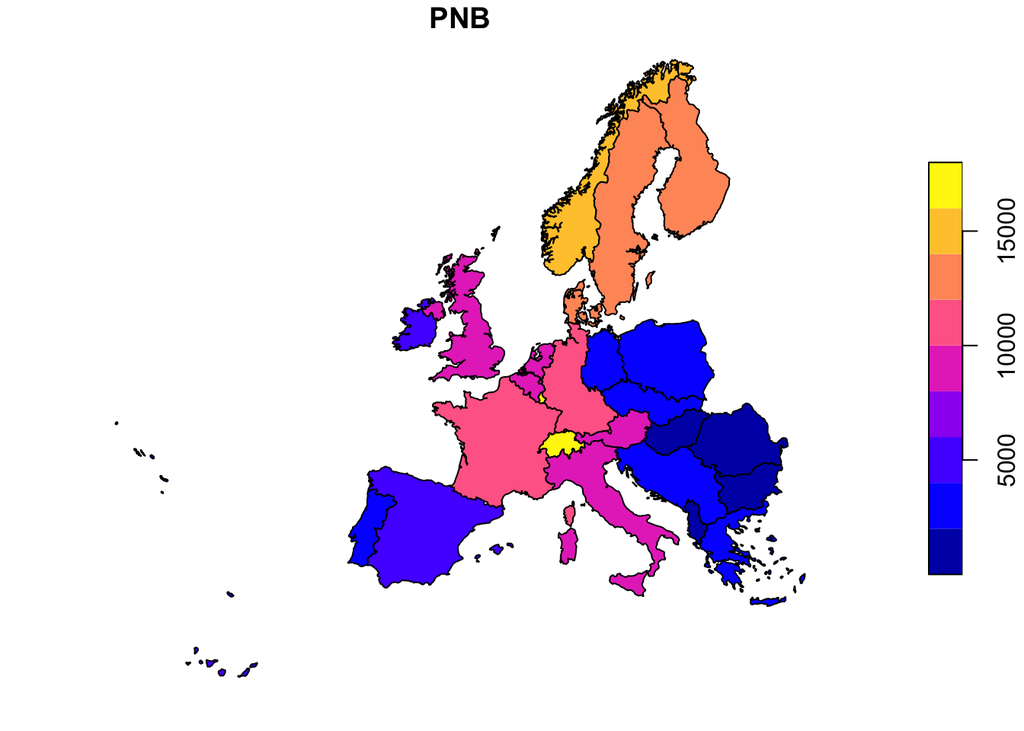

```r
plot(mapdon["PNB"])
```

### Sauvegarde du fichier sf

```r
saveRDS(mapdon,"carto/europe88/europe88_sf.RDS")
```

## Importation à l’aide de packages

Nous allons essayer de constituer une carte des émissions de CO2 par habitant dans le Monde 2018 basée sur la combinaison des données `wbstats` et du fonds de carte gadm du package `geodata`.

### Importation du fonds de carte

On charge le fonds de carte des pays du Monde du package geodata

```r
library(geodata)
map<-world(resolution=5, path=tempdir())
worldmap<-st_as_sf(map)
saveRDS(worldmap, "carto/world/worldmap.RDS")
```

### Importation des données statistiques

On importe les données statistiques correspondant aux pays qui ont été retenus dans le fonds de carte. Pour cela on utilise l’API de la banque mondiale

```r
library(wbstats)
df   <- wb_data(indicator  = c("SP.POP.TOTL", "EN.ATM.CO2E.KT"),
                return_wide = TRUE,
                start_date = 2018,
                end_date = 2018)
```

Nous renommons les variables pour avoir un tableau plus simple ou la population est en millions d’habitants, les émissions de CO2 en millions de tonnes. On y ajoute l’intensité des émissions en tonnes par habitant. Puis on sauvegarder le tout.

```r
don <-df %>% select(iso3 = iso3c,  POP = SP.POP.TOTL, CO2 = EN.ATM.CO2E.KT) %>%
            mutate(POP = POP/1000000, CO2 = CO2/1000, CO2_hab = CO2/POP)
kable(head(don),digits = 2)
saveRDS(don, "carto/world/worlddon.RDS")
```

[output not shown]

### Jointure

```r
map<-readRDS("carto/world/worldmap.RDS")
don<-readRDS("carto/world/worlddon.RDS")
mapdon <- merge(map, don,
                by.x="GID_0",
                by.y="iso3",
                all.x=T,
                all.y = F)
kable(head(mapdon))
```

| GID_0 | NAME_0 | POP | CO2 | CO2_hab | geometry |
| --- | --- | --- | --- | --- | --- |
| ABW | Aruba | 0.105962 | NA | NA | POLYGON ((-69.9782 12.46986… |
| AFG | Afghanistan | 36.686784 | 6.07 | 0.1654547 | POLYGON ((74.89049 37.23569… |
| AGO | Angola | 31.273533 | 23.96 | 0.7661430 | MULTIPOLYGON (((23.9957 -10… |
| ALA | Åland | NA | NA | NA | MULTIPOLYGON (((19.62865 60… |
| ALB | Albania | 2.866376 | 5.11 | 1.7827389 | POLYGON ((20.03311 42.54832… |
| AND | Andorra | 0.075013 | 0.49 | 6.5322012 | POLYGON ((1.721942 42.50123… |

### Essai de cartographie

On réalise ici une belle carte avec le package **mapsf** qui sera expliqué plus loin

```r
library(mapsf)
mf_theme("agolalight")
  mf_map(x= mapdon,
         var = "CO2_hab",
         type = "choro",
         breaks="jenks",
         leg_pos="bottomleft",
         leg_title = "en tonnes/hab.")
  mf_map(x= mapdon,
         var = "CO2",
         type = "prop",
         inches = 0.2,
         col="red",
         leg_pos = "topleft",
         leg_title = "en millions de tonnes")
```

```
44 'NA' values are not plotted on the map.
```

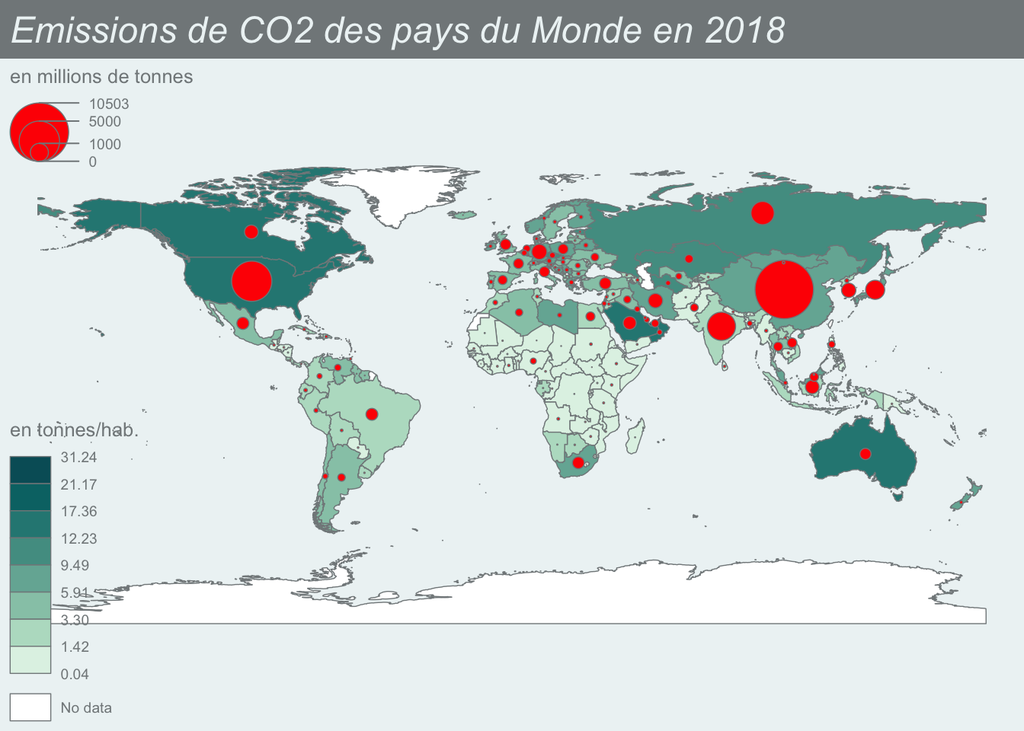

```r
mf_title("Emissions de CO2 des pays du Monde en 2018")
```

### Sauvegarde du fichier sf

```r
saveRDS(mapdon,"carto/world/worldmapCO2.RDS")
```

## Importation au format GEOJSON

La plupart des API permettent de récupérer directement des fichiers combinant les données statistiques et cartographiques au format GEOJSON. Il suffit alors de les convertir au format sf en une seule opération, sans avoir besoin d’effectuer de jointure.

### Récupération d’un fichier GEOJSON

On commence par repérer une url permettant de récupérer un fichier de type GeoJSON. Puis on récupère le fichier et on l’enregistre à l’aide de la fonction `dowload.file()` en lui donnat l’extension *.geojson*. Ce fichier pourra être utilisé dans d’autres langages de programmation comme Python.

```r
myurl<- "https://public.opendatasoft.com/api/explore/v2.1/catalog/datasets/georef-france-commune/exports/geojson?lang=fr&refine=reg_name%3A%22%C3%8Ele-de-France%22&timezone=Europe%2FBerlin"



download.file(url=myurl,
              destfile="carto/idfcom/idfcom.geojson",
              method="curl")
```

### Conversion du fichier geojson au format sf

On convertit le fichier geojson au format sf à l’aide de la fonction `geojson_sf()`du package **geojsonsf**. On vérifie que le fichier est bien de la bonne classe

```r
mapdon<-geojson_sf("carto/idfcom/idfcom.geojson")
class(mapdon)
```

```
[1] "sf"         "data.frame"
```

### Sélection des variables

On ne conserve que la colonne code et on ajoute une colonne département

```r
mapdon<-mapdon %>% select(com_code) %>%
  mutate(com_code = substr(com_code,3,7),
         depcode = substr(com_code,1,2))
head(mapdon)
```

```
Simple feature collection with 6 features and 2 fields
Geometry type: POLYGON
Dimension:     XY
Bounding box:  xmin: 2.584831 ymin: 48.49468 xmax: 3.48622 ymax: 48.91068
Geodetic CRS:  WGS 84
  com_code                       geometry depcode
1    77072 POLYGON ((3.411219 48.54254...      77
2    77075 POLYGON ((2.775456 48.91034...      77
3    77081 POLYGON ((2.738851 48.6351,...      77
4    77151 POLYGON ((3.156655 48.6999,...      77
5    77152 POLYGON ((2.641049 48.49468...      77
6    77192 POLYGON ((2.896519 48.68125...      77
```

### Essai de cartographie

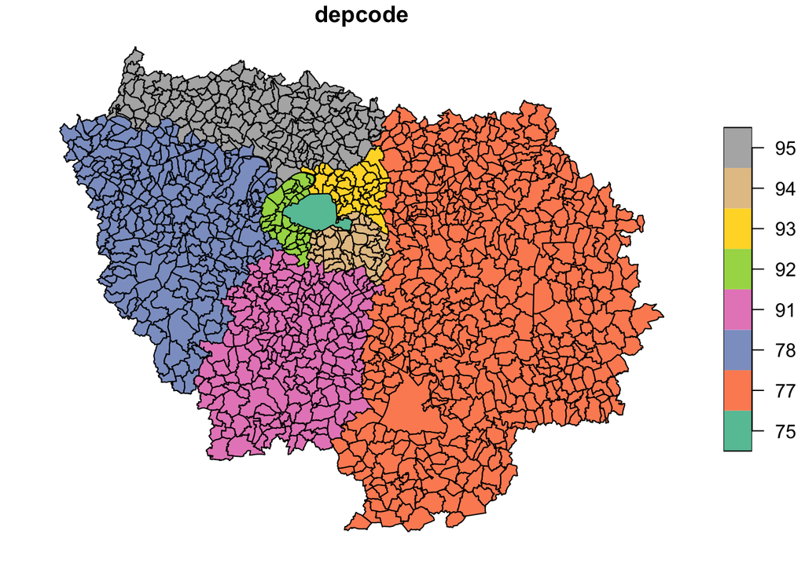

```r
plot(mapdon["depcode"])
```

### Sauvegarde au format sf

```r
saveRDS(mapdon,"carto/idfcom/idfcom.RDS")
```